# jodatut

Tarkistetaan aluksi mitä versioita kaikista tarvittavista kirjastoista on käytössä:

```python
import sys
print('Python: {}'.format(sys.version))
import scipy
print('scipy: {}'.format(scipy.__version__))
import numpy
print('numpy: {}'.format(numpy.__version__))
import matplotlib
print('matplotlib: {}'.format(matplotlib.__version__))
import pandas
print('pandas: {}'.format(pandas.__version__))
import sklearn
print('sklearn: {}'.format(sklearn.__version__))
import seaborn
print('seaborn: {}'.format(seaborn.__version__))
```

```
Python: 3.6.4 |Anaconda, Inc.| (default, Jan 16 2018, 10:22:32) [MSC v.1900 64 bit (AMD64)]
scipy: 1.0.0
numpy: 1.14.0
matplotlib: 2.1.2
pandas: 0.22.0
sklearn: 0.19.1
seaborn: 0.8.1
```

Luetaan data käyttöön:

```python
url = "https://raw.githubusercontent.com/tommiollila/desktop/master/trafficAmountJodatut.csv"
dataset = pandas.read_csv(url)
```

Katsotaan miltä data näyttää:

```python
print(dataset)
```

```
     device detector  traffic   time
0    tre133      a60        0  00-01
1    tre133     a_31        0  00-01
2    tre133    b60_1        0  00-01
3    tre133    b60_2        0  00-01
4    tre133   b_55_1        0  00-01
5    tre133   b_55_2        0  00-01
6    tre133      c60        0  00-01
7    tre133      d50        0  00-01
8    tre133   e_41_1        0  00-01
9    tre133   e_41_2        0  00-01
10   tre133      f50        0  00-01
11   tre133      a60        0  01-02
12   tre133     a_31        0  01-02
13   tre133    b60_1       60  01-02
```

[output cut: 49 more lines]

Tutkitaan hieman ensin datan muuttujia pylväsdiagrammilla:

```python
import matplotlib.pyplot as plt
```

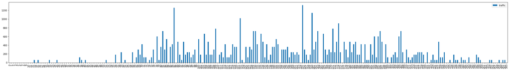

```python
dataset.plot.bar(figsize=(40,5))
plt.show()
```

Otetaan myös nopea katsaus dataan sisältöön taulukkomuodossa:

```python
print(dataset.describe())
```

```
           traffic
count   264.000000
mean    188.409091
std     236.026452
min       0.000000
25%       0.000000
50%     120.000000
75%     300.000000
max    1320.000000
```

Nämä eivät kuitenkaan vielä juuri dataa paljon tarkemmin kuvaa. Seuraavaksi muodostetaan diagrammit siitä, miten ajan mukaan liikenteenmäärän keskiarvo risteyksessä vaihtelee.

```python
time_dataset = dataset.groupby('time').mean()
```

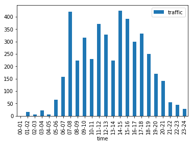

```python
time_dataset.plot.bar()
plt.show()
```

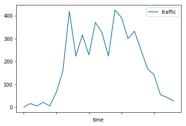

```python
time_dataset.plot()
plt.show()
```

Tehdään vielä sama vertailu, mutta jokaiselle risteyksen laitteelle erikseen. Eli näytetään visuaalisesti se, kuinka eri puolilla kyseistä risteystä on liikenneruuhkaa ajankodan suhteen.

[figure not shown]

[figure not shown]

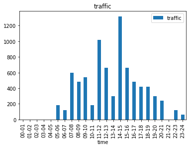

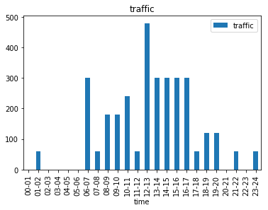

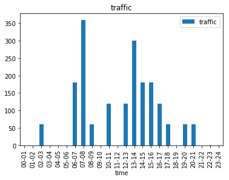

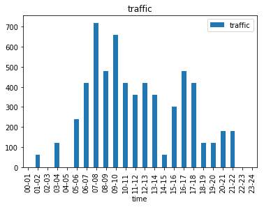

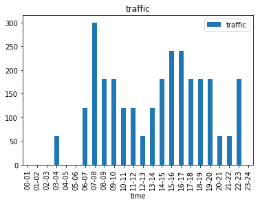

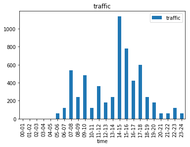

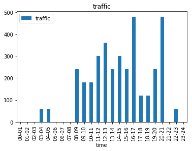

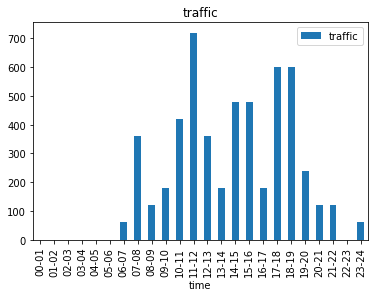

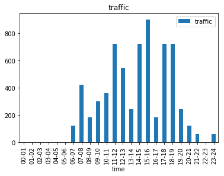

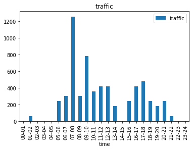

| detector | traffic count | traffic mean | traffic std | traffic min | traffic 25% | traffic 50% | traffic 75% | traffic max |
| --- | --- | --- | --- | --- | --- | --- | --- | --- |
| a60 | 24.0 | 0.0 | 0.000000 | 0.0 | 0.0 | 0.0 | 0.0 | 0.0 |
| a_31 | 24.0 | 337.5 | 343.906585 | 0.0 | 45.0 | 270.0 | 495.0 | 1320.0 |
| b60_1 | 24.0 | 132.5 | 137.025862 | 0.0 | 0.0 | 60.0 | 255.0 | 480.0 |
| b60_2 | 24.0 | 77.5 | 100.833483 | 0.0 | 0.0 | 60.0 | 120.0 | 360.0 |
| b_55_1 | 24.0 | 255.0 | 216.875039 | 0.0 | 60.0 | 210.0 | 420.0 | 720.0 |
| b_55_2 | 24.0 | 115.0 | 90.072435 | 0.0 | 45.0 | 120.0 | 180.0 | 300.0 |
| c60 | 24.0 | 250.0 | 286.750914 | 0.0 | 60.0 | 150.0 | 375.0 | 1140.0 |
| d50 | 24.0 | 152.5 | 154.223158 | 0.0 | 0.0 | 120.0 | 240.0 | 480.0 |
| e_41_1 | 24.0 | 220.0 | 226.351016 | 0.0 | 0.0 | 150.0 | 375.0 | 720.0 |
| e_41_2 | 24.0 | 275.0 | 292.827297 | 0.0 | 0.0 | 180.0 | 450.0 | 900.0 |
| f50 | 24.0 | 257.5 | 293.127810 | 0.0 | 0.0 | 240.0 | 375.0 | 1260.0 |

```python
avgtype = dataset.groupby('detector')
avgtype.plot.bar(x='time')
plt.show()
avgtype.describe()
```

Näytetään vielä liikenteen ruuhkan määrä keskiarvollisesti jokaisessa kohdassa risteystä.

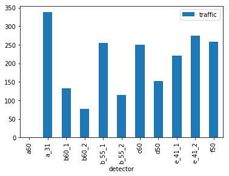

```python
avgtype = dataset.groupby('detector').mean()
avgtype.plot.bar()
plt.show()
```

Dataa on nyt perinteisin menetelmin jonkun verran kuvailtu. Tästä datasta ei juuri vielä saa tehtyä analyysia, joten keräsin sitä lisää. Edellisessä datasetissä oli liikennedataa yhdestä risteyksestä vain maanantailta. Keräsin nyt samasta risteyksestä datan yhdeltä viikolta jokaiselta viikonpäivältä. Näistä liikennetiedoista sitten päästiin tekemään analyysia.

```python
url2 = "https://raw.githubusercontent.com/tommiollila/desktop/master/trafficAmountJodatut4.csv"
dataset2 = pandas.read_csv(url2)
```

```python
print(dataset2)
```

```
     device detector   time  traffic_monday  traffic_tuesday  \
0    tre133      a60  00-01               0                0
1    tre133     a_31  00-01               0                0
2    tre133    b60_1  00-01               0                0
3    tre133    b60_2  00-01               0                0
4    tre133   b_55_1  00-01               0                0
5    tre133   b_55_2  00-01               0               60
6    tre133      c60  00-01               0               60
7    tre133      d50  00-01               0                0
8    tre133   e_41_1  00-01               0               60
9    tre133   e_41_2  00-01               0               60
10   tre133      f50  00-01               0                0
11   tre133      a60  01-02               0                0
12   tre133     a_31  01-02               0                0
13   tre133    b60_1  01-02              60                0
```

[output cut: 175 more lines]

Seuraavaksi tehdään lineaarista mallinnusta liikenteestä ja piirretään lineaarisia regressiosuoria.

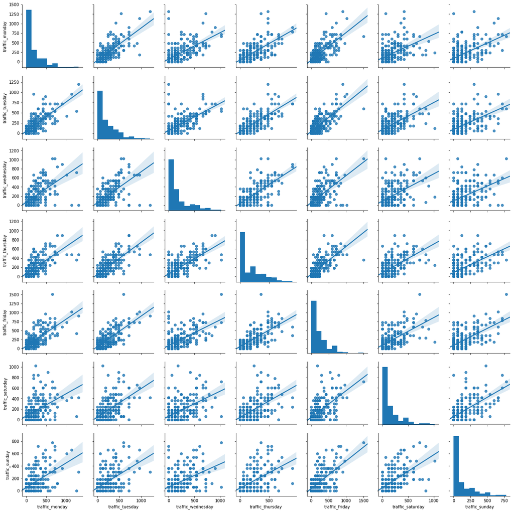

```python
from sklearn import linear_model
import seaborn as sns

sns.pairplot(dataset2, kind="reg")
plt.show()
```

Ja lasketaan vielä korrelaatiot liikennemäärien välille.

```python
print(dataset2.corr())
```

```
                   traffic_monday  traffic_tuesday  traffic_wednesday  \
traffic_monday           1.000000         0.777090           0.643002
traffic_tuesday          0.777090         1.000000           0.672593
traffic_wednesday        0.643002         0.672593           1.000000
traffic_thursday         0.716321         0.778319           0.743914
traffic_friday           0.734680         0.764731           0.651529
traffic_saturday         0.510971         0.598497           0.534283
traffic_sunday           0.562692         0.564089           0.490934

                   traffic_thursday  traffic_friday  traffic_saturday  \
traffic_monday             0.716321        0.734680          0.510971
traffic_tuesday            0.778319        0.764731          0.598497
traffic_wednesday          0.743914        0.651529          0.534283
traffic_thursday           1.000000        0.748183          0.628474
traffic_friday             0.748183        1.000000          0.621661
traffic_saturday           0.628474        0.621661          1.000000
traffic_sunday             0.585972        0.646926          0.626586

                   traffic_sunday
traffic_monday           0.562692
traffic_tuesday          0.564089
traffic_wednesday        0.490934
traffic_thursday         0.585972
traffic_friday           0.646926
traffic_saturday         0.626586
traffic_sunday           1.000000
```

Nyt voidaan katsoa luotuja analyyseja ja tulla siihen tulokseen, että kuvaajia sekä korrelaatiotaulukkoa katsomalla voitaisiin tämän viikon datan perusteella ennustaa, että maanantain dataa voisi käyttää parhaiten ennustamaan tiistain liikennettä. Toinen esimerkki mitä datasta löytyy on, että korrelaatioiden perusteella lauantain ja sunnuntain liikennettä ei juuri voida ennustaa minkään arkipäivän datan avulla.

Mallia voitaisiin vielä parantaa esimerkiksi niin, että otetaan dataa useammalta viikolta. Tässä on kuitenkin lähtökohta sille, kuinka datasta voi helposti tehdä analyysiä liikennemäärän ennustamisesta.

Tähän olen vielä kuvannut esimerkiksi maanantain ja tiistain välisen liikennemäärän lineaarisen regressiosuoran.

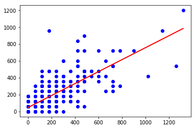

```python
clf = linear_model.LinearRegression()
import numpy as np

X = dataset2['traffic_monday'].values[:, np.newaxis]
y = dataset2['traffic_tuesday']

classifier = clf.fit(X, y)

plt.scatter(X, y, color='b')
plt.plot(X, classifier.predict(X), color='r')

plt.show()
```